# Homework 3 template

Tam Nguyen

September 27th, 2018

# Part 1: EDA

1. Create a matrix of scatterplots of the three variables TotalPrice, Carat, and Depth. Do Carat and Depth appear to have a linear (or other) relationship with TotalPrice?

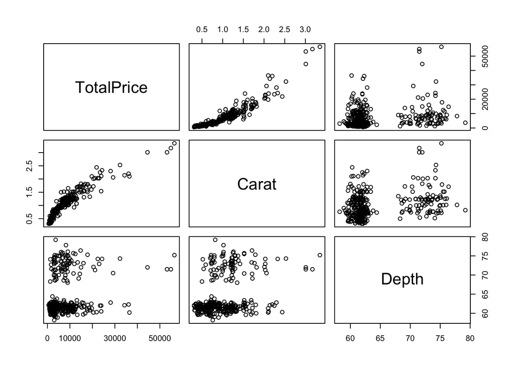

```r
pairs(~TotalPrice+Carat+Depth,data=Diamonds)
```

- Carat and Total price appears to have a quadratic relationship since all points make a slighly curvy line.
- However, Depth with Total price doesn’t appear to have a linear relationship. They make two packs of points that don’t correlated to each other.
- Overall, we can’t see an obvious linear relationship between Carat vs TotalTime and Depth vs TotalTime.

2. ```
    Find a matrix of correlations among these three variables. Compare these results with your visual analysis in (a). Which explanatory variable (Carat or Depth) has the highest correlation with TotalPrice?  Is this consistent with your visual assessment?
   ```

```r
cor(~cbind(Carat,Depth,TotalPrice),data=Diamonds)
```

```
##                Carat     Depth TotalPrice
## Carat      1.0000000 0.3202687  0.9291358
## Depth      0.3202687 1.0000000  0.2177839
## TotalPrice 0.9291358 0.2177839  1.0000000
```

- As we expected, the Carat does have higher correlation to TotalPrice than Depth variable.
3. Would you consider Carat and Depth to be “highly correlated” with each other?
- The scatter plot above shows no linear relationship between Carat and Depth.
- There is no strong correlation between Carat and Depth, since r = 0.32, which is really weak.

# Part 2: Complete problems 3.23 - 3.26

## 3.23: Diamonds

### a.

A quadratic model using Depth:

```r
model.a <- lm(TotalPrice~Depth+I(Depth^2),data=Diamonds); summary(model.a)
```

```
##
## Call:
## lm(formula = TotalPrice ~ Depth + I(Depth^2), data = Diamonds)
##
## Residuals:
##    Min     1Q Median     3Q    Max
##  -9323  -4251  -2676   2134  45513
##
## Coefficients:
##               Estimate Std. Error t value Pr(>|t|)
## (Intercept) -28406.783 112211.790  -0.253    0.800
## Depth          766.369   3353.222   0.229    0.819
## I(Depth^2)      -3.233     24.869  -0.130    0.897
##
## Residual standard error: 7616 on 348 degrees of freedom
## Multiple R-squared:  0.04748,    Adjusted R-squared:  0.042
## F-statistic: 8.673 on 2 and 348 DF,  p-value: 0.0002111
```

- R-square = 4.7%
- Adj Rsq = 4.2%

There is no significant in this model, so we exclude it in the comparision part.

### b.

Two predictor models: Carat and Depth

```r
model.b <- lm(TotalPrice~Depth+Carat, data = Diamonds);
summary (model.b)
```

```
##
## Call:
## lm(formula = TotalPrice ~ Depth + Carat, data = Diamonds)
##
## Residuals:
##     Min      1Q  Median      3Q     Max
## -9234.7 -1223.7  -274.3  1161.0 16368.6
##
## Coefficients:
##             Estimate Std. Error t value Pr(>|t|)
## (Intercept)  1059.24    1918.36   0.552    0.581
## Depth        -134.94      30.92  -4.364 1.68e-05 ***
## Carat       15087.01     320.96  47.006  < 2e-16 ***
## ---
## Signif. codes:  0 '***' 0.001 '**' 0.01 '*' 0.05 '.' 0.1 ' ' 1
##
## Residual standard error: 2809 on 348 degrees of freedom
## Multiple R-squared:  0.8704, Adjusted R-squared:  0.8696
## F-statistic:  1168 on 2 and 348 DF,  p-value: < 2.2e-16
```

- R-square = 87.0%
- Adj Rsq = 87.0%
- Depth and Carat are significant variables in this model since the their p-value ~ 0. ### c. Three predictor model that adds interaction for Carat and Depth

```r
model.c <- lm(formula = TotalPrice ~Carat*Depth, data=Diamonds);
summary(model.c);
```

```
##
## Call:
## lm(formula = TotalPrice ~ Carat * Depth, data = Diamonds)
##
## Residuals:
##     Min      1Q  Median      3Q     Max
## -8254.4 -1311.5  -157.2  1131.8 14513.9
##
## Coefficients:
##              Estimate Std. Error t value Pr(>|t|)
## (Intercept)  31171.41    4219.58   7.387 1.13e-12 ***
## Carat       -11827.73    3436.47  -3.442 0.000648 ***
## Depth         -598.18      65.47  -9.137  < 2e-16 ***
## Carat:Depth    408.45      51.96   7.861 4.84e-14 ***
## ---
## Signif. codes:  0 '***' 0.001 '**' 0.01 '*' 0.05 '.' 0.1 ' ' 1
##
## Residual standard error: 2592 on 347 degrees of freedom
## Multiple R-squared:   0.89,  Adjusted R-squared:  0.889
## F-statistic: 935.7 on 3 and 347 DF,  p-value: < 2.2e-16
```

- R-square = 89%
- Adj Rsq = 88.9%
- Carat*Depth, Carat, and Depth are three significant variables in this model since their p-value ~ 0. ### d. Complete second-order model using Carat and Depth

```r
model.d <- lm(TotalPrice~I(Carat^2) + I(Depth^2) + Carat*Depth, data = Diamonds);
summary(model.d)
```

```
##
## Call:
## lm(formula = TotalPrice ~ I(Carat^2) + I(Depth^2) + Carat * Depth,
##     data = Diamonds)
##
## Residuals:
##      Min       1Q   Median       3Q      Max
## -12196.1   -652.7    -38.5    485.7  10582.2
##
## Coefficients:
##              Estimate Std. Error t value Pr(>|t|)
## (Intercept) 24338.820  30297.912   0.803   0.4223
## I(Carat^2)   4761.592    330.246  14.418   <2e-16 ***
## I(Depth^2)      5.276      6.727   0.784   0.4333
## Carat        7573.620   3040.787   2.491   0.0132 *
## Depth        -728.700    904.439  -0.806   0.4210
## Carat:Depth   -83.891     53.530  -1.567   0.1180
## ---
## Signif. codes:  0 '***' 0.001 '**' 0.01 '*' 0.05 '.' 0.1 ' ' 1
##
## Residual standard error: 2053 on 345 degrees of freedom
## Multiple R-squared:  0.9313, Adjusted R-squared:  0.9304
## F-statistic: 936.1 on 5 and 345 DF,  p-value: < 2.2e-16
```

## 3.24: Diamonds (continued)

### a.

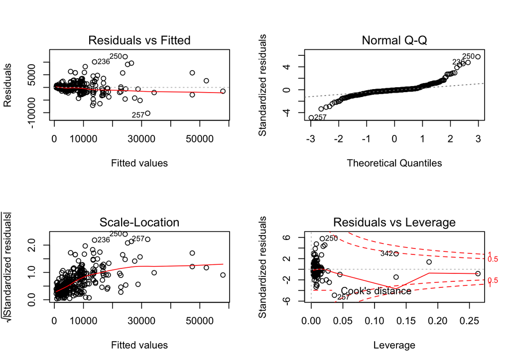

```r
model.quad <- lm(TotalPrice~Carat+I(Carat^2),data=Diamonds);
par(mfrow=c(2,2))
plot(model.quad)
```

- The normal Q-Q model doesn’t look good. The tails of both sides look really messy with many outliners.
- The residuals vs fitted values graph doesn’t look good too, since all points compact to one side, which indicating non-constant variance in the residuals.

### b. ln(TotalPrice)

```r
logmod.a <- lm(log(TotalPrice)~Depth+I(Depth^2),data=Diamonds); summary(logmod.a)
```

```
##
## Call:
## lm(formula = log(TotalPrice) ~ Depth + I(Depth^2), data = Diamonds)
##
## Residuals:
##     Min      1Q  Median      3Q     Max
## -2.1323 -0.6091 -0.1150  0.6217  2.1351
##
## Coefficients:
##               Estimate Std. Error t value Pr(>|t|)
## (Intercept)  9.2516568 12.3981256   0.746    0.456
## Depth       -0.0605669  0.3704928  -0.163    0.870
## I(Depth^2)   0.0007626  0.0027477   0.278    0.782
##
## Residual standard error: 0.8415 on 348 degrees of freedom
## Multiple R-squared:  0.06262,    Adjusted R-squared:  0.05723
## F-statistic: 11.62 on 2 and 348 DF,  p-value: 1.298e-05
```

- R-square: 6.26%
- Adj R-square: 5.723%
- No significant predictor.

```r
logmod.b <- lm(log(TotalPrice)~Depth+Carat, data = Diamonds);
summary (logmod.b)
```

```
##
## Call:
## lm(formula = log(TotalPrice) ~ Depth + Carat, data = Diamonds)
##
## Residuals:
##      Min       1Q   Median       3Q      Max
## -1.38177 -0.13236  0.01812  0.21550  0.92948
##
## Coefficients:
##              Estimate Std. Error t value Pr(>|t|)
## (Intercept)  7.445406   0.223436   33.32   <2e-16 ***
## Depth       -0.008752   0.003601   -2.43   0.0156 *
## Carat        1.652443   0.037383   44.20   <2e-16 ***
## ---
## Signif. codes:  0 '***' 0.001 '**' 0.01 '*' 0.05 '.' 0.1 ' ' 1
##
## Residual standard error: 0.3272 on 348 degrees of freedom
## Multiple R-squared:  0.8583, Adjusted R-squared:  0.8574
## F-statistic:  1054 on 2 and 348 DF,  p-value: < 2.2e-16
```

- R-square: 85.83%
- Adj-square: 85.74%
- Significant factors: Carat, Depth (p-value ~ 0)

```r
logmod.c <- lm(log(TotalPrice) ~Carat*Depth, data=Diamonds);
summary(logmod.c)
```

```
##
## Call:
## lm(formula = log(TotalPrice) ~ Carat * Depth, data = Diamonds)
##
## Residuals:
##      Min       1Q   Median       3Q      Max
## -1.36271 -0.14008  0.03185  0.18673  0.93288
##
## Coefficients:
##              Estimate Std. Error t value Pr(>|t|)
## (Intercept)  3.846674   0.489146   7.864 4.75e-14 ***
## Carat        4.869049   0.398366  12.223  < 2e-16 ***
## Depth        0.046610   0.007589   6.142 2.24e-09 ***
## Carat:Depth -0.048814   0.006023  -8.105 9.15e-15 ***
## ---
## Signif. codes:  0 '***' 0.001 '**' 0.01 '*' 0.05 '.' 0.1 ' ' 1
##
## Residual standard error: 0.3005 on 347 degrees of freedom
## Multiple R-squared:  0.8808, Adjusted R-squared:  0.8798
## F-statistic: 854.8 on 3 and 347 DF,  p-value: < 2.2e-16
```

- R-square: 88.08%
- Adj square: 87.98%
- Significant Factor: Carat, Depth, Carat*Depth (p-value ~ 0)

```r
logmod.d <- lm(log(TotalPrice)~I(Carat^2) + I(Depth^2) + Carat*Depth, data = Diamonds);
summary(logmod.d)
```

```
##
## Call:
## lm(formula = log(TotalPrice) ~ I(Carat^2) + I(Depth^2) + Carat *
##     Depth, data = Diamonds)
##
## Residuals:
##      Min       1Q   Median       3Q      Max
## -0.85021 -0.13209  0.01441  0.13613  0.79710
##
## Coefficients:
##               Estimate Std. Error t value Pr(>|t|)
## (Intercept) 13.5049624  3.4020467   3.970 8.76e-05 ***
## I(Carat^2)  -0.5714071  0.0370821 -15.409  < 2e-16 ***
## I(Depth^2)   0.0013384  0.0007553   1.772   0.0773 .
## Carat        2.5863485  0.3414393   7.575 3.33e-13 ***
## Depth       -0.2027689  0.1015563  -1.997   0.0467 *
## Carat:Depth  0.0095943  0.0060107   1.596   0.1114
## ---
## Signif. codes:  0 '***' 0.001 '**' 0.01 '*' 0.05 '.' 0.1 ' ' 1
##
## Residual standard error: 0.2306 on 345 degrees of freedom
## Multiple R-squared:  0.9302, Adjusted R-squared:  0.9292
## F-statistic: 919.9 on 5 and 345 DF,  p-value: < 2.2e-16
```

```r
logmod.e <- lm(log(TotalPrice)~Carat+I(Carat^2),data=Diamonds);
summary(logmod.e)
```

```
##
## Call:
## lm(formula = log(TotalPrice) ~ Carat + I(Carat^2), data = Diamonds)
##
## Residuals:
##     Min      1Q  Median      3Q     Max
## -0.8215 -0.1313  0.0003  0.1391  0.8615
##
## Coefficients:
##             Estimate Std. Error t value Pr(>|t|)
## (Intercept)  6.13042    0.05218  117.48   <2e-16 ***
## Carat        3.05963    0.08422   36.33   <2e-16 ***
## I(Carat^2)  -0.52730    0.02944  -17.91   <2e-16 ***
## ---
## Signif. codes:  0 '***' 0.001 '**' 0.01 '*' 0.05 '.' 0.1 ' ' 1
##
## Residual standard error: 0.238 on 348 degrees of freedom
## Multiple R-squared:  0.925,  Adjusted R-squared:  0.9246
## F-statistic:  2146 on 2 and 348 DF,  p-value: < 2.2e-16
```

- R-square: 92.5%
- Adj R-square: 92.46%
- Significant factors: Carat, $Carat^2$

```r
logmod.f <- lm(log(TotalPrice)~Carat+I(Carat^2)+I(Carat^3),data=Diamonds);
summary(logmod.f)
```

```
##
## Call:
## lm(formula = log(TotalPrice) ~ Carat + I(Carat^2) + I(Carat^3),
##     data = Diamonds)
##
## Residuals:
##      Min       1Q   Median       3Q      Max
## -0.80289 -0.12604 -0.00678  0.13125  0.80255
##
## Coefficients:
##             Estimate Std. Error t value Pr(>|t|)
## (Intercept)  5.62372    0.09256  60.755  < 2e-16 ***
## Carat        4.46314    0.23106  19.316  < 2e-16 ***
## I(Carat^2)  -1.58885    0.16639  -9.549  < 2e-16 ***
## I(Carat^3)   0.22193    0.03430   6.471 3.32e-10 ***
## ---
## Signif. codes:  0 '***' 0.001 '**' 0.01 '*' 0.05 '.' 0.1 ' ' 1
##
## Residual standard error: 0.2252 on 347 degrees of freedom
## Multiple R-squared:  0.9331, Adjusted R-squared:  0.9325
## F-statistic:  1613 on 3 and 347 DF,  p-value: < 2.2e-16
```

- R-square: 93.31%
- Adj R-square: 93.25%
- Significant factors: Carat, $Carat^2$, $Carat^3$

#### Conclustion

- With high adjusted $R^{2}$ value and small amount of variables, quadratic regression model still the best one.

### c.

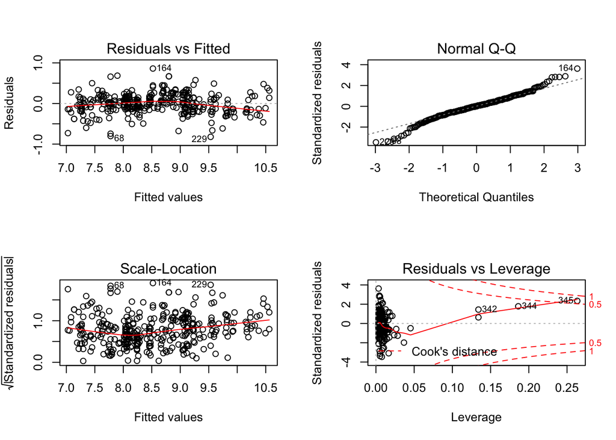

```r
par(mfrow=c(2,2))
plot(logmod.e)
```

- Normal Q-Q: does look better even there’s still some taling off at the end of the graph.
- The log transformation helps the residuals vs fitted values look random with constant variance.

## 3.25: Diamonds

```r
anova(model.quad, model.d, test="F")
```

```
## Analysis of Variance Table
##
## Model 1: TotalPrice ~ Carat + I(Carat^2)
## Model 2: TotalPrice ~ I(Carat^2) + I(Depth^2) + Carat * Depth
##   Res.Df        RSS Df Sum of Sq      F   Pr(>F)
## 1    348 1574044410
## 2    345 1454702094  3 119342316 9.4345 5.24e-06 ***
## ---
## Signif. codes:  0 '***' 0.001 '**' 0.01 '*' 0.05 '.' 0.1 ' ' 1
```

- The p-value (~5.24e-06) ~0, which gives strong evidence that at least one of the terms involving Depth should be included in the model.
- Therefore, eliminating all three Depth factor would badly affect the performance of model.

## 3.26: Diamonds

### a.

```r
predict.lm(model.quad, data.frame("Carat" = 0.5), interval = "confidence")
```

```
##        fit      lwr      upr
## 1 1794.843 1424.296 2165.389
```

```r
predict.lm(model.quad, data.frame("Carat" = 0.5), interval = "prediction")
```

```
##        fit       lwr      upr
## 1 1794.843 -2404.462 5994.147
```

- Our quadratic model predicts total price of a 0.5 carat diamond could be 1794.843$

### b.

- We are 95% confident that the average price of all 0.5-carat diamonds is between $1424 and $2165.
- But this does not mean that your particular 0.5-carat diamond will be in this range. This only show the price average of all such diamonds will be in this range.

### c.

- According to our model, 95% of all 0.5-carat diamonds will cost between $0 and $5994 (since the money should start from a positive number).
- We confident say that your 0.5-carat diamon will be in this range.

### d.

```r
t_conf = predict.lm(logmod.e, data.frame("Carat" = 0.5), interval = "confidence");
exp(t_conf)
```

```
##        fit      lwr      upr
## 1 1860.149 1784.588 1938.908
```

- We are 95% confident that the average price of all 0.5-carat diamonds is between $1784.588 and $1938.908
- However, it doesn’t mean that your particular 0.5 carat diamond will be in this range.

```r
t_pred = predict.lm(logmod.e, data.frame("Carat" = 0.5), interval = "prediction");
exp(t_pred)
```

```
##        fit      lwr     upr
## 1 1860.149 1162.651 2976.09
```

- According to our model, 95% of all 0.5-carat diamonds will cost between $1162.651 and $2976.09.
- It means that your 0.5-carat diamond will 95% in the range $1162.651 and $2976.09.